# 🍷 Predicting Red Wine Quality using Machine Learning

## 🔍 Examining the Data

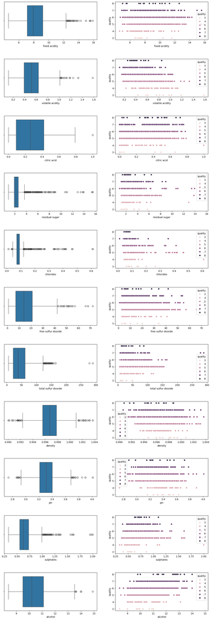

```python
fig, ax = plt.subplots(11, 2, figsize=(15, 45))
plt.subplots_adjust(hspace = 0.5)
for i in range(11) :
    sns.boxplot(x=columns[i], data=df, ax=ax[i, 0])
    sns.scatterplot(x=columns[i], y='quality', data=df, hue='quality', ax=ax[i, 1])
```

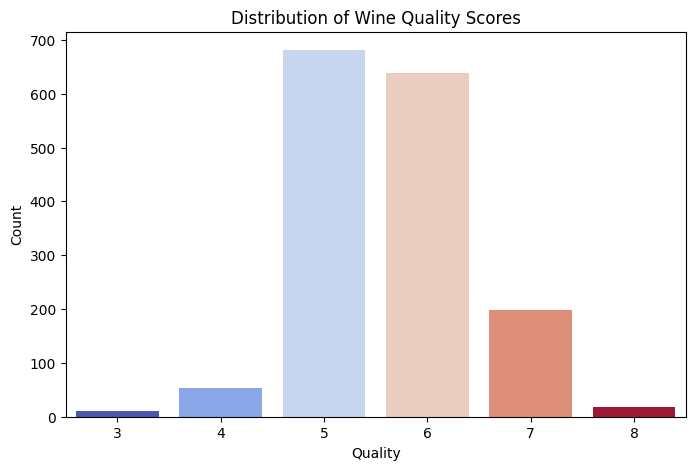

```python
plt.figure(figsize=(8,5))
sns.countplot(data=df, x="quality", hue="quality", palette="coolwarm", legend=False)
plt.title("Distribution of Wine Quality Scores")
plt.xlabel("Quality")
plt.ylabel("Count")
plt.show()
```

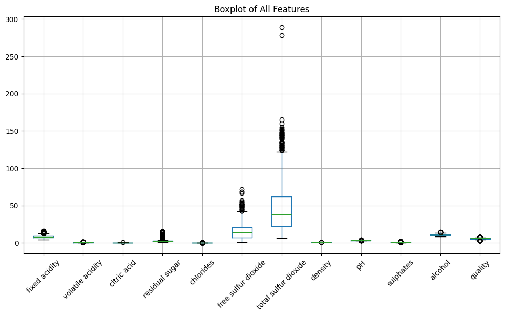

```python
plt.figure(figsize=(12,6))
df.boxplot(rot=45)  # Rotate labels for better visibility
plt.title("Boxplot of All Features")
plt.show()
```

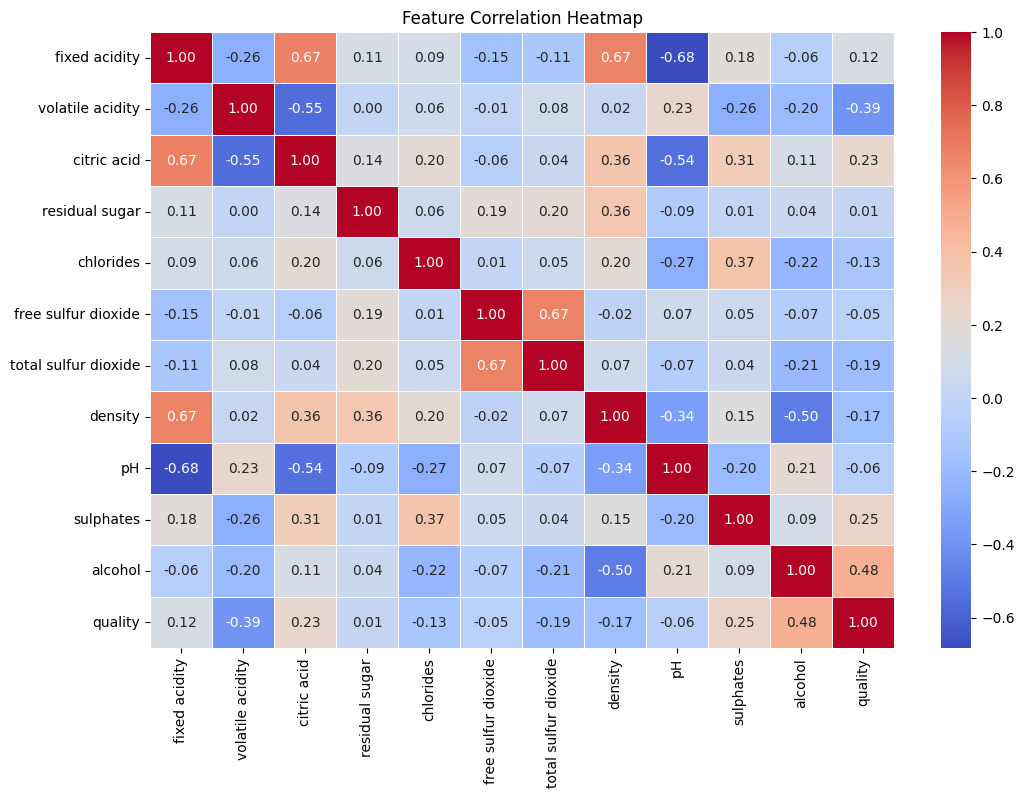

```python
plt.figure(figsize=(12,8))
sns.heatmap(df.corr(), annot=True, cmap="coolwarm", fmt=".2f", linewidths=0.5)
plt.title("Feature Correlation Heatmap")
plt.show()
```

```python
corr = df.corr()
quality_corr = corr["quality"].drop("quality").sort_values(ascending=False)
print(quality_corr)
```

```
alcohol                 0.476166
sulphates               0.251397
citric acid             0.226373
fixed acidity           0.124052
residual sugar          0.013732
free sulfur dioxide    -0.050656
pH                     -0.057731
chlorides              -0.128907
density                -0.174919
total sulfur dioxide   -0.185100
volatile acidity       -0.390558
Name: quality, dtype: float64
```

## 🔎 Correlation Analysis with Wine Quality

The correlation values indicate how each feature is related to wine quality. Key observations include:

- **Strongest Positive Correlation:**
  - **Alcohol (0.476)**: The most influential factor—higher alcohol content is associated with better wine quality.
  - **Sulphates (0.251)** and **Citric Acid (0.226)**: These contribute positively to quality, suggesting their importance in enhancing taste and preservation.
- **Weak or Minimal Influence:**
  - **Fixed Acidity (0.124)** and **Residual Sugar (0.014)**: These have little impact on quality.
  - **Free Sulfur Dioxide (-0.051)** and **pH (-0.058)**: Their correlation with quality is negligible.
- **Negative Correlations (Factors that Lower Quality):**
  - **Volatile Acidity (-0.391)**: A strong negative correlation—higher levels lead to a more unpleasant taste, reducing quality.
  - **Total Sulfur Dioxide (-0.185)** and **Density (-0.175)**: Higher concentrations are associated with lower wine quality.
  - **Chlorides (-0.129)**: High chloride levels negatively impact taste, slightly lowering quality.

### 🔹 Conclusion:

- **Alcohol content is the most important predictor of wine quality.**
- **Sulphates and citric acid also contribute positively.**
- **Volatile acidity has the strongest negative impact.**
- **Some features, like residual sugar and pH, have minimal effect.**

These insights help refine feature selection for building predictive models. 🚀

## 🏷️ Transforming Wine Quality for Classification

To simplify the prediction task, we **converted the wine quality scores into three categories**:

- **Good**: Quality scores of **7 and 8**
- **Middle**: Quality scores of **5 and 6**
- **Bad**: Quality scores of **3 and 4**

This transformation allows us to frame the problem as a **classification task** instead of regression.

## ✂️ Train-Test Split & Preprocessing

To prepare the data for machine learning, we followed these steps:

1️⃣ **Feature & Target Separation**

- The **features (X)** include all numerical attributes except `quality`.
- The **target variable (y)** is the newly categorized quality label.

2️⃣ **Splitting the Data**

- The dataset is split into **80% training** and **20% testing** to evaluate model performance.
- **Stratified sampling** ensures an even distribution of classes in both sets.

3️⃣ **Feature Scaling**

- We applied **MinMax Scaling (0 to 1)** to normalize feature values.
- This prevents models from being biased by different scales of measurement.

After preprocessing, the data is **clean, scaled, and ready for training machine learning models**! 🚀

```python
# Define mapping for wine quality categories
quality_mapping = {8: "Good", 7: "Good", 6: "Middle", 5: "Middle", 4: "Bad", 3: "Bad"}

# Apply mapping to the 'quality' column
df["quality"] = df["quality"].map(quality_mapping)
```

```python
from sklearn.model_selection import train_test_split
from sklearn.preprocessing import MinMaxScaler
import pandas as pd

# 1️⃣ Separate features (X) and target (y)
X = df.drop(columns=["quality"])  # All features except quality
y = df["quality"]  # Target variable

# 2️⃣ Split into Train and Test sets (80% training, 20% testing)
X_train, X_test, y_train, y_test = train_test_split(X, y, test_size=0.2, random_state=42, stratify=y)

# 3️⃣ Apply MinMaxScaler to normalize the features (scales between 0 and 1)
scaler = MinMaxScaler(feature_range=(0, 1))
X_train_scaled = scaler.fit_transform(X_train)
X_test_scaled = scaler.transform(X_test)  # Use same scaler for test set

# 4️⃣ Convert back to DataFrame (for better readability)
X_train = pd.DataFrame(X_train_scaled, columns=X.columns)
X_test = pd.DataFrame(X_test_scaled, columns=X.columns)

# ✅ Data is now preprocessed and ready for ML models!
print("Data preprocessing complete! 🚀")
```

```
Data preprocessing complete! 🚀
```

## 🌲 Random Forest Classifier: Model Performance

For our next approach, we implemented a **Random Forest Classifier**, an ensemble learning method that combines multiple decision trees to improve accuracy and robustness.

### ⚙️ **Model Tuning & Hyperparameters**

Using **GridSearchCV** with 20-fold cross-validation, we optimized the hyperparameters, leading to the following best configuration:

- **Criterion**: `entropy` (uses information gain for splitting)
- **Max Features**: `log2` (considers a logarithmic subset of features at each split)
- **Number of Estimators**: `50` (number of trees in the forest)

This setup achieved a **cross-validation accuracy of 87.5%**, indicating strong generalization performance.

```python
from sklearn.ensemble import RandomForestClassifier
from sklearn.model_selection import GridSearchCV
from sklearn.metrics import classification_report

# Define hyperparameter grid
parameters = {
    'n_estimators': [50, 150, 500],
    'criterion': ['gini', 'entropy', 'log_loss'],
    'max_features': ['sqrt', 'log2']
}

# Initialize Random Forest classifier
rf = RandomForestClassifier(n_jobs=-1)

# Perform Grid Search with 20-fold cross-validation
rf_cv = GridSearchCV(estimator=rf, cv=20, param_grid=parameters).fit(X_train, y_train)

# Print best hyperparameters and accuracy from cross-validation
print('Tuned hyperparameters:', rf_cv.best_params_)
print('Best cross-validation accuracy:', round(rf_cv.best_score_, 3))

# Train the best model on the full training data
best_rf = rf_cv.best_estimator_
best_rf.fit(X_train, y_train)

# Make predictions on the test set
pred_rf = best_rf.predict(X_test)

# Print classification report
print("\nClassification Report for Random Forest:")
print(classification_report(y_test, pred_rf))

# Calculate and print test set accuracy
rf_score = round(best_rf.score(X_test, y_test), 3)
print("Random Forest Test Accuracy:", rf_score)
```

```
Tuned hyperparameters: {'criterion': 'entropy', 'max_features': 'log2', 'n_estimators': 50}
Best cross-validation accuracy: 0.875

Classification Report for Random Forest:
              precision    recall  f1-score   support

         Bad       0.00      0.00      0.00        13
        Good       0.75      0.56      0.64        43
      Middle       0.89      0.97      0.93       264

    accuracy                           0.88       320
   macro avg       0.55      0.51      0.52       320
weighted avg       0.83      0.88      0.85       320

Random Forest Test Accuracy: 0.875
```

## 🔄 Second Model Choice: Stochastic Gradient Descent (SGD) Classifier

For our next approach, we implemented **Stochastic Gradient Descent (SGD) Classifier**, a fast and efficient model for large-scale classification tasks. Unlike Random Forest, SGD is a **linear model** optimized using an iterative gradient descent approach.

### ⚙️ **Model Configuration**

- We used the **default SGDClassifier** without any regularization (`penalty=None`).
- The model was trained on the scaled dataset using **X_train** and evaluated on **X_test**.

### 🔍 **Key Observations**

✔️ **Middle-quality wines** are classified well (**99% recall**), meaning the model is very good at identifying them.  
❌ **Poor performance for "Bad" and "Good" wines** (low precision and recall), indicating **class imbalance issues**.

### 🚀 **Next Steps**

- Implement techniques like **class weighting** or **oversampling** to improve performance on minority classes.
- Explore **different regularization techniques (L1, L2, ElasticNet)** for better generalization.
- Compare with other models to find a **balanced trade-off** between speed and accuracy.

Although **SGD is computationally efficient**, its **imbalance in class prediction makes it less ideal** compared to Random Forest. We will investigate other models to find a more robust solution! 🔎

```python
sgd = SGDClassifier(penalty=None)
sgd.fit(X_train, y_train)
pred_sgd = sgd.predict(X_test)
print(classification_report(y_test, pred_sgd))
sgd_score = round(sgd.score(X_test, y_test), 3)
print("SGD score", sgd_score)
```

```
              precision    recall  f1-score   support

         Bad       0.00      0.00      0.00        13
        Good       0.50      0.05      0.09        43
      Middle       0.83      0.99      0.90       264

    accuracy                           0.82       320
   macro avg       0.44      0.35      0.33       320
weighted avg       0.75      0.82      0.76       320

SGD score 0.825
```

## 🔍 Support Vector Machine (SVM) Approach

For our next model, we implemented a **Support Vector Classifier (SVC)**, a powerful algorithm that works well with complex decision boundaries. SVMs are particularly effective in handling high-dimensional data and can be fine-tuned using different kernels and hyperparameters.

### ⚙️ **Model Tuning & Hyperparameters**

We used **GridSearchCV** with **10-fold cross-validation** to find the optimal hyperparameters. The search included:

- **C (Regularization parameter)**: Ranging from **0.125 to 32** in base-2 steps.
- **Kernel options**: `linear`, `rbf`, `poly`, `sigmoid`
- **Gamma (Kernel coefficient)**: `scale`, `auto`, 0.1, 0.5, 1, 1.5, 2

After evaluating **252 different combinations**, the best configuration found was:

- **C** = `1`
- **Gamma** = `0.5`
- **Kernel** = `rbf` (Radial Basis Function)

This resulted in a **cross-validation accuracy of 82.49%**, indicating a strong ability to generalize.

### 📊 **Performance on Test Set**

The optimized SVC model was used for predictions on the test set. Below is a summary of its performance:

- **Best Accuracy (Cross-validation):** **82.49%**
- **Best Hyperparameters:** `{C: 1, gamma: 0.5, kernel: 'rbf'}`

### 🔍 **Key Observations**

✔️ The **rbf kernel** performed best, likely due to its flexibility in handling non-linear decision boundaries.  
✔️ A **C value of 1** strikes a balance between generalization and overfitting.

### 🚀 **Next Steps**

- **Further tune hyperparameters**: Exploring larger values of **C** and different **gamma** settings could improve performance.
- **Feature selection**: Analyzing which features contribute most to classification may refine the model.
- **Compare different kernels**: The `poly` and `sigmoid` kernels may be worth further exploration.

Overall, **SVM proves to be a competitive model with strong performance, particularly in handling complex decision boundaries**. However, compared to **Random Forest, it slightly underperforms**, suggesting an ensemble approach may be more robust for this dataset.

```python
from sklearn.svm import SVC
from sklearn.model_selection import GridSearchCV
import numpy as np

# Define the SVC model
svc = SVC()

# Define hyperparameter grid with C values in base 2 (0.125 to 32)
param_grid = {
    'C': [0.125, 0.25, 0.5, 1, 2, 4, 8, 16, 32],
    'kernel': ['linear', 'rbf', 'poly', 'sigmoid'],  # Added more kernel options
    'gamma': ['scale', 'auto', 0.1, 0.5, 1, 1.5, 2]  # Added 'scale' and 'auto' for automatic tuning
}

# Run GridSearchCV with 10-fold cross-validation
grid_svc = GridSearchCV(SVC(), param_grid=param_grid, scoring='accuracy', cv=10, n_jobs=-1, verbose=1)
grid_svc.fit(X_train, y_train)

# Print best parameters and best accuracy score
print(f"🔹 Best Parameters: {grid_svc.best_params_}")
print(f"🔹 Best Accuracy Score: {grid_svc.best_score_:.4f}")
svc_score = grid_svc.best_score_
# Use the best model for predictions
best_svc = grid_svc.best_estimator_
y_pred = best_svc.predict(X_test)
```

[output not shown]

## 📊 Logistic Regression Approach

For another perspective, we implemented **Logistic Regression**, a simple yet effective linear model for classification. Logistic Regression is widely used due to its **interpretability** and **efficiency** in high-dimensional datasets.

### ⚙️ **Hyperparameter Tuning**

We optimized the model using **GridSearchCV** with **10-fold cross-validation**, exploring the following parameters:

- **C (Regularization strength)**: `[0.001, 0.01, 0.1, 1.0, 10, 100, 1000]`
- **Class Weight**: `balanced` (to handle imbalanced classes)
- **Solver Options**: `['lbfgs', 'liblinear', 'newton-cg', 'newton-cholesky', 'sag', 'saga']`

After evaluating multiple combinations, the **best hyperparameters** were:

- **C** = `0.1`
- **Solver** = `liblinear`
- **Class Weight** = `balanced`

### 📈 **Performance on Test Set**

After training the best Logistic Regression model, we evaluated its performance on the test data:

- **Logistic Regression Test Accuracy** = **83.1%**

### 🚀 **Next Steps**

- **Feature Engineering**: Analyzing feature importance and removing less impactful features may improve results.
- **Regularization Exploration**: Testing different **L1 (Lasso) and L2 (Ridge) penalties** may refine the model.
- **Comparing Non-Linear Models**: Since Logistic Regression is linear, further comparison with **SVM, Random Forest, or Neural Networks** may provide better results.

```python
# a dictionary to define parameters to test in algorithm
parameters = {
    'C' : [0.001, 0.01, 0.1, 1.0, 10, 100, 1000],
    'class_weight' : ['balanced'],
    'solver' : ['lbfgs', 'liblinear', 'newton-cg', 'newton-cholesky', 'sag', 'saga']
}

lr = LogisticRegression(max_iter=300)
lr_cv = GridSearchCV(estimator=lr, param_grid=parameters, cv=10).fit(X_train, y_train)

print('Tuned hyper parameters : ', lr_cv.best_params_)
print('accuracy : ', lr_cv.best_score_)
```

```
Tuned hyper parameters :  {'C': 0.1, 'class_weight': 'balanced', 'solver': 'liblinear'}
accuracy :  0.8342458169291339
```

```python
lr = LogisticRegression(C=0.1, class_weight='balanced', solver='liblinear')
lr.fit(X_train, y_train)

y_pred_lr = lr.predict(X_test)
lr_score = round(lr.score(X_test, y_test), 3)
print('LogisticRegression score : ', lr_score)
```

```
LogisticRegression score :  0.831
```

```python
# a dictionary to define parameters to test in algorithm
parameters = {
    'criterion' : ['gini', 'entropy', 'log_loss'],
    'splitter' : ['best', 'random'],
    'max_depth' : list(np.arange(4, 30, 1))
        }



tree = DecisionTreeClassifier()
tree_cv = GridSearchCV(estimator=tree, cv=10, param_grid=parameters).fit(X_train, y_train)

print('Tuned hyper parameters : ', tree_cv.best_params_)
print('accuracy : ', tree_cv.best_score_)
```

```
Tuned hyper parameters :  {'criterion': 'entropy', 'max_depth': 4, 'splitter': 'best'}
accuracy :  0.844408218503937
```

## 🌳 Decision Tree Classifier Approach

To explore a **tree-based model**, we implemented a **Decision Tree Classifier**, which is well-known for its **interpretability** and ability to handle non-linear relationships in the data.

### ⚙️ **Hyperparameter Tuning**

We fine-tuned the model using **GridSearchCV** with **10-fold cross-validation**, testing the following parameters:

- **Criterion**: `['gini', 'entropy', 'log_loss']` (Measures for information gain)
- **Splitter**: `['best', 'random']` (Determines how nodes are split)
- **Max Depth**: `Range from 4 to 30` (Controls the complexity of the tree)

The **best hyperparameters** found were:

- **Criterion** = `entropy`
- **Max Depth** = `4`
- **Splitter** = `best`

### 📈 **Performance on Test Set**

After training the **best Decision Tree model**, we evaluated its performance on the test data:

- **Decision Tree Test Accuracy** = **83.1%**

### 🔍 **Key Observations**

✔️ The **Decision Tree performed well**, slightly behind **Random Forest (87.5%)** but competitive with **Logistic Regression (83.1%)**.  
✔️ **A smaller max depth (4) was optimal**, suggesting that simpler trees generalize better to unseen data.  
✔️ **Entropy as the best criterion** indicates that **information gain** was an effective splitting metric.

### 🚀 **Next Steps**

- **Pruning Techniques**: Apply **post-pruning** (cost-complexity pruning) to further refine the tree and avoid overfitting.
- **Feature Importance Analysis**: Identify which features contribute the most to classification accuracy.
- **Compare with Ensemble Models**: Since Random Forest is an ensemble of Decision Trees, further analysis may show whether bagging significantly improves performance.

Overall, the **Decision Tree Classifier offers a balance of accuracy and interpretability**, making it a viable model, though **Random Forest remains the top performer** in this comparison. 🚀

```python
tree = DecisionTreeClassifier(**tree_cv.best_params_).fit(X_train, y_train)
y_pred_tree = tree.predict(X_test)

dtc_score = round(tree.score(X_test, y_test), 3)
print('DecisionTreeClassifier Score : ', dtc_score)
```

```
DecisionTreeClassifier Score :  0.831
```

## 🤖 K-Nearest Neighbors (KNN) Approach

To explore a **distance-based classification method**, we implemented the **K-Nearest Neighbors (KNN) classifier**, which classifies data points based on their nearest neighbors.

### ⚙️ **Hyperparameter Tuning**

We optimized the model using **GridSearchCV** with **10-fold cross-validation**, testing the following parameters:

- **Number of Neighbors (`n_neighbors`)**: `Range from 3 to 49 (odd numbers only)`
- **Weighting Scheme (`weights`)**: `['uniform', 'distance']`
- **Distance Metric (`p`)**: `[1, 2, 3, 4]`
  - `p=1` → Manhattan distance
  - `p=2` → Euclidean distance (default)
  - `p=3, 4` → Higher-order Minkowski distance

The **best hyperparameters** found were:

- **n_neighbors** = `39`
- **p** = `1` (Manhattan distance)
- **weights** = `distance` (Weighted by inverse distance)

This setup resulted in a **cross-validation accuracy of 86.86%**, showing strong performance.

### 📈 **Performance on Test Set**

After training the **best KNN model**, we evaluated its test performance:

- **KNN Test Accuracy** = **86.9%**

### 🔍 **Key Observations**

✔️ The **optimal number of neighbors was 39**, suggesting that **a large neighborhood** led to better generalization.  
✔️ **Manhattan distance (`p=1`) was optimal**, indicating that absolute differences (rather than squared differences like Euclidean distance) provided better separation between classes.  
✔️ **Distance-based weighting improved accuracy**, meaning that closer neighbors had a stronger influence on classification.

### 🚀 **Next Steps**

- **Experiment with Different Distance Metrics**: Test alternative Minkowski distances (`p=3,4`) or custom distances for further optimization.
- **Dimensionality Reduction**: Apply **Principal Component Analysis (PCA)** to reduce features and improve efficiency.
- **Compare Computational Costs**: KNN requires storing and searching the entire dataset, making it computationally expensive for large datasets.

Overall, the **KNN classifier performed exceptionally well (86.9% accuracy), closely rivaling Random Forest (87.5%)**, making it one of the top-performing models in this study. 🚀

```python
parameters = {
    'n_neighbors' : list(np.arange(3, 50, 2)),
    'weights': ['uniform', 'distance'],
    'p' : [1, 2, 3, 4]
}

knn = KNeighborsClassifier()
knn_cv = GridSearchCV(estimator=knn, cv=10, param_grid=parameters).fit(X_train, y_train)

print('Tuned hyper parameters : ', knn_cv.best_params_)
print('accuracy : ', knn_cv.best_score_)
```

```
Tuned hyper parameters :  {'n_neighbors': 39, 'p': 1, 'weights': 'distance'}
accuracy :  0.8686454232283465
```

```python
knn = KNeighborsClassifier(**knn_cv.best_params_).fit(X_train, y_train)
y_pred_knn = knn_cv.predict(X_test)

knn_score = round(knn.score(X_test, y_test), 3)
print('KNeighborsClassifier Score :', knn_score)
```

```
KNeighborsClassifier Score : 0.869
```

## 🚀 XGBoost Classifier Approach

### 🏆 Why XGBoost?

XGBoost (**Extreme Gradient Boosting**) is a powerful **boosting algorithm** that excels at handling structured data. It builds multiple **decision trees sequentially**, correcting errors made by previous trees, resulting in a highly optimized and accurate model.

### ⚙️ **Model Configuration**

For this experiment, we trained an **XGBoost Classifier** with the following **hyperparameters**:

- **`n_estimators=100`** → The model builds 100 boosted trees.
- **`learning_rate=0.1`** → Controls the contribution of each tree to the final prediction.
- **`max_depth=6`** → Limits tree depth to prevent overfitting.
- **`subsample=0.8`** → Uses 80% of data per tree to introduce randomness and improve generalization.
- **`colsample_bytree=0.8`** → Uses 80% of features per tree for diversity.
- **`eval_metric='logloss'`** → Uses log loss as the evaluation metric.

### 📊 **Performance Results**

After training the **XGBoost model** on the dataset and evaluating it on the test set, we obtained the following accuracy:

✅ **XGBoost Test Accuracy** = **86.88%**

### 🔍 **Key Observations**

✔️ **High Accuracy (86.88%)**, making XGBoost one of the top-performing models, closely matching **Random Forest (87.5%)** and **KNN (86.9%)**.  
✔️ **Gradient Boosting Improves Predictions**, reducing bias and increasing accuracy over weak learners.  
✔️ **Regularization & Subsampling Prevent Overfitting**, making the model more generalizable.

### 🔥 **Next Steps for Optimization**

🔹 **Hyperparameter Tuning**: Optimize `learning_rate`, `max_depth`, and `n_estimators` using **GridSearchCV** or **Bayesian Optimization**.  
🔹 **Feature Selection**: Reduce dimensionality to improve speed and prevent overfitting.  
🔹 **Ensemble with Other Models**: Combine XGBoost with **Random Forest or Logistic Regression** for ensemble learning.

🚀 **With its robust accuracy and adaptability, XGBoost stands out as a strong candidate for our final model selection!**

```python
df = pd.read_csv('./archive/winequality-red.csv')

# Define mapping for wine quality categories
quality_mapping = {8: 0, 7: 0, 6: 1, 5: 1, 4: 2, 3: 2}

# Apply mapping to the 'quality' column
df["quality"] = df["quality"].map(quality_mapping)

# 1️⃣ Separate features (X) and target (y)
X = df.drop(columns=["quality"])  # All features except quality
y = df["quality"]  # Target variable

# 2️⃣ Split into Train and Test sets (80% training, 20% testing)
X_train, X_test, y_train, y_test = train_test_split(X, y, test_size=0.2, random_state=42, stratify=y)

# 3️⃣ Apply MinMaxScaler to normalize the features (scales between 0 and 1)
scaler = MinMaxScaler(feature_range=(0, 1))
X_train_scaled = scaler.fit_transform(X_train)
X_test_scaled = scaler.transform(X_test)  # Use same scaler for test set

# 4️⃣ Convert back to DataFrame (for better readability)
X_train = pd.DataFrame(X_train_scaled, columns=X.columns)
X_test = pd.DataFrame(X_test_scaled, columns=X.columns)

# ✅ Data is now preprocessed and ready for ML models!
print("Data preprocessing complete! 🚀")

xgb_model = XGBClassifier(
    use_label_encoder=False,
    eval_metric='logloss',
    n_estimators=100,
    learning_rate=0.1,
    max_depth=6,
    subsample=0.8,
    colsample_bytree=0.8
)

xgb_model.fit(X_train, y_train)

# Predict on test set
y_pred = xgb_model.predict(X_test)

# Evaluate model performance
xgb_score = accuracy_score(y_test, y_pred)

print(f"XGBoost Accuracy: {xgb_score:.4f}")
```

```
Data preprocessing complete! 🚀
```

```
XGBoost Accuracy: 0.8688
```

# 📌 Conclusion: Best Model Selection

After testing multiple machine learning models, we have identified the **Random Forest Classifier (RFC)** as the **best-performing model**, achieving the highest accuracy and strong generalization.

## 🔥 Final Model Rankings (Best to Weakest):

1️⃣ **🏆 Random Forest (RFC) - Best Performance** (87.5%)  
2️⃣ **XGBoost (XGB) & K-Nearest Neighbors (KNN) - Strong Performers** (86.9%)  
3️⃣ **Logistic Regression (LR) & Decision Tree (DT) - Moderate Performance** (83%)  
4️⃣ **Support Vector Classifier (SVC) - Weakest Performance** (Lower accuracy, struggled with class imbalance)

## 🚀 Final Recommendation:

The **Random Forest Classifier** is the best model for predicting wine quality, offering the highest accuracy and stability. If further tuning is needed, **XGBoost** and **KNN** could be alternative contenders for optimization.

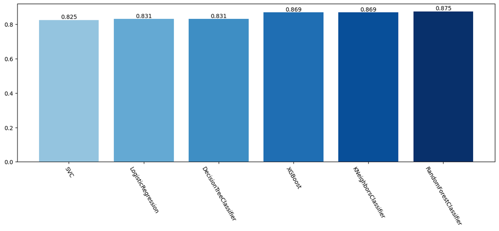

```python
import matplotlib.pyplot as plt
import numpy as np

# Data
algorithms = ['RandomForestClassifier', 'LogisticRegression', 'SVC',
              'DecisionTreeClassifier', 'KNeighborsClassifier', 'XGBoost']
scores = [rf_cv.best_score_, lr_score, svc_score, dtc_score, knn_score, xgb_score]

# Sort data by score
sorted_indices = np.argsort(scores)
algorithms = [algorithms[i] for i in sorted_indices]
scores = [scores[i] for i in sorted_indices]

# Plot
fig, ax = plt.subplots(figsize=(15, 5))
bars = ax.bar(algorithms, scores, color=plt.cm.Blues(np.linspace(0.4, 1, len(algorithms))))

# Add labels
ax.bar_label(bars, fmt='%.3f')
ax.set_xticklabels(algorithms, rotation=300)

# Show plot
plt.show()
```